# **FigEngine: A High-Performance Structured Figure Engine**

##### **1. 导入库**

```python
import os
import sys
# 导入FigEngine库
import figengine as fe
```

```python
# 定义常量
DPI = 600
```

##### **2. 可打印的基础信息**

```python
# 打印FigEngine库基础信息
print(f"version: {fe.__version__}")
print(f"file: {fe.__file__}")
print(f"author: {fe.__author__}")
print(f"author email: {fe.__author_email__}")
print(f"license: {fe.__license__}")
fe.Tools.print_valid_fonts()
```

[output not shown]

[output cut: 100 more lines]

```
Tlwg Typo                     URW Bookman                   URW Gothic
Ubuntu                        Umpush                        UnBatang
UnDinaru                      UnDotum                       UnGraphic
UnGungseo                     UnJamoBatang                  UnJamoDotum
UnJamoNovel                   UnJamoSora                    UnPen
UnPenheulim                   UnPilgi                       UnPilgia
UnShinmun                     UnTaza                        UnVada
UnYetgul                      Universalis ADF Std           Waree
Work Sans                     Yeseva One                    Z003
cmex10                        cmmi10                        cmr10
cmsy10                        dsrom10                       esint10
eufm10                        msam10                        msbm10
rsfs10                        stmary10                      wasy10

============================================================
```

[output not shown]

[output cut: 377 more lines]

[output not shown]

##### **3. 日志系统等级设置**

```python
# 初始化日志记录系统
logger = fe.setup_logger(level="Warning")
```

##### **4. 读取图片创建Image对象**

**函数签名:**

`fe.Image(source, label, dpi)`

**参数:**

- `source`: 文件路径或已经创建的Image对象。(支持: `.jpg`, `.png`, `.svg`, `.pdf`, `.tif`)
- `label`: 图像标签, 后续可用于生成子图编号
- `dpi`: 图像分辨率(默认 300), 如果 source 是文件且包含 DPI 信息，则自动读取

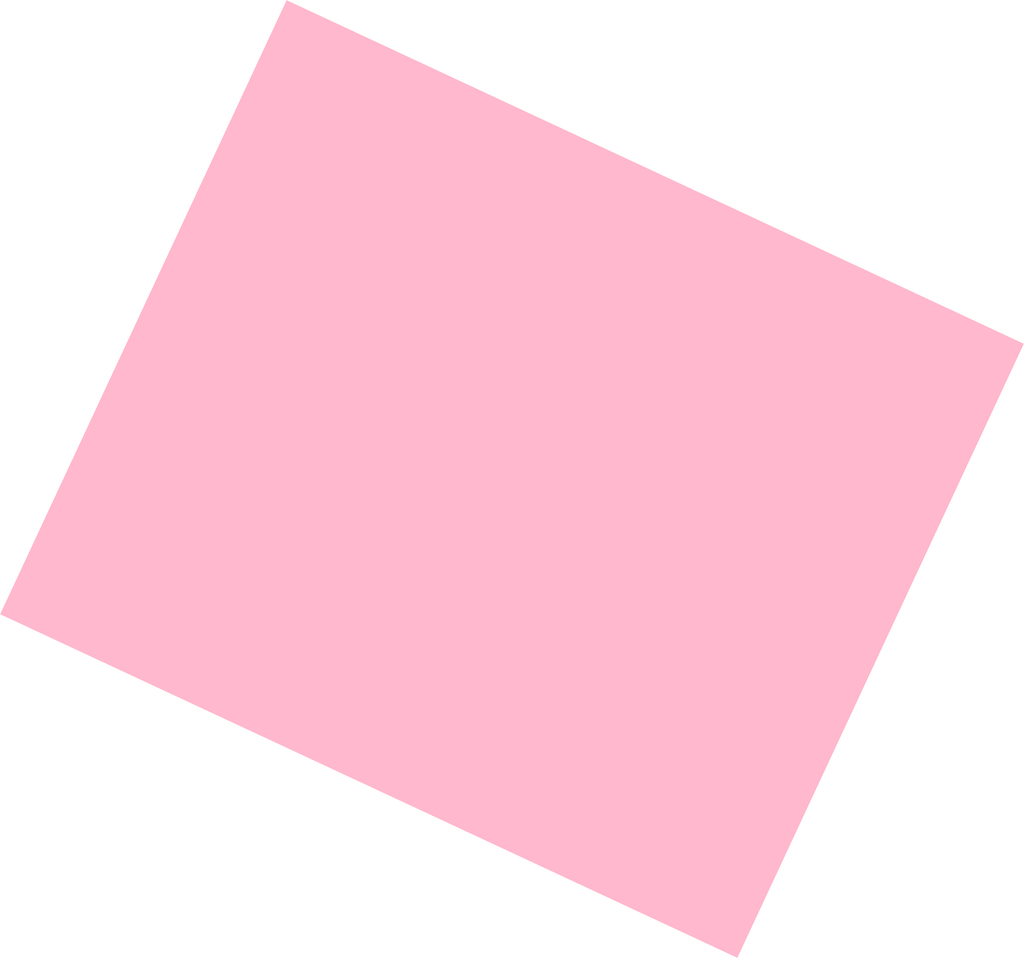

```python
# 从文件加载一个Image对象
img2 = fe.Image(source="assets/img1_rotated_neg25.png", dpi=DPI, label="Test Image from File")
img2.show(width=500)
```

##### **5. 创建空白的Image对象**

**函数签名:**

`fe.Image.new(size, facecolor, unit, dpi, label)`

**参数:**

- `size`: 图像尺寸 (width, height)
- `facecolor`: 背景颜色(默认白色)
- `unit`: 尺寸单位(支持: "pixel", "inch", "cm", "mm"，默认 "inch")
- `dpi`: 图像分辨率(默认 300)
- `label`: 图像标签, 后续可用于生成子图编号

```python
# 创建一个空白的Image对象
img1 = fe.Image.new(size=(6.0, 5.0), facecolor="#FFB8CD", unit="inch", dpi=DPI, label="Test Image")
```

##### **6. 图片属性**

**函数签名:**

`Image.size`

`Image.get_size(unit)`

**尺寸:**

- `Image.size`: 图片尺寸(以像素为单位)
- `Image.get_size(unit)`: 图片尺寸，(unit支持: "pixel", "inch", "cm", "mm"，默认 "pixel")

**分辨率:**

- `Image.dpi`: 图片分辨率

**标签:**

- `Image.label`: 图像标签

```python
print(f"img1.size: {img1.size}")
print(f"img1.get_size(pixel): {img1.get_size('pixel')}")   # 打印像素尺寸
print(f"img1.get_size(inch): {img1.get_size('inch')}")     # 打印英寸尺寸
print(f"img1.get_size(cm): {img1.get_size('cm')}")         # 打印厘米尺寸
print(f"img1.get_size(mm): {img1.get_size('mm')}")         # 打印毫米尺寸
print(f"img1.dpi: {img1.dpi}")                               # 打印DPI值
print(f"img1.label: {img1.label}")                             # 打印图像模式
```

```
img1.size: (3600, 3000)
img1.get_size(pixel): (3600, 3000)
img1.get_size(inch): (6.0, 5.0)
img1.get_size(cm): (15.24, 12.7)
img1.get_size(mm): (152.39999999999998, 127.0)
img1.dpi: 600
img1.label: Test Image
```

##### **7. 调整图片大小**

**函数签名:**

`Image.resize(width, height, scale, ref_image, unit, resample)`

**参数:**

- `width`: 图像宽度
- `height`: 图像高度
- `scale`: 缩放比例
- `ref_image`: 参考图片
- `unit`: 尺寸单位（支持: "pixel", "inch", "cm", "mm"，默认 "pixel"）
- `resample`: 插值算法
  - `"auto"`: 智能选择（放大用 bicubic，缩小用 lanczos）, 默认方案
  - `"lanczos"`: 高质量缩小
  - `"bicubic"`: 平滑放大
  - `"nearest"`: 最近邻（保硬边）

```python
# 调整图像大小
print("原始比例", img1.size, img1.get_size("inch"), img1.get_size("cm"))

# 强制指定高度和宽度
img2 = img1.resize(width=4.0, height=2.5, unit="inch")
print("强制指定高度和宽度", img2.size, img1.get_size("inch"), img1.get_size("cm"))

# 仅指定宽度，高度等比例缩放
img3 = img1.resize(width=4.0, unit="inch")
print("仅指定宽度，高度等比例缩放", img3.size, img3.get_size("inch"), img3.get_size("cm"))

# 仅指定高度，宽度等比例缩放
img4 = img1.resize(height=10, unit="cm")
print("仅指定高度，宽度等比例缩放", img4.size, img4.get_size("inch"), img4.get_size("cm"))

# 按比例缩放50%
img5 = img1.resize(scale=0.5)
print("按比例缩放50%", img5.size, img5.get_size("inch"), img5.get_size("cm"))

# 参照另一张图像的大小进行缩放
img6 = img1.resize(ref_image=img2)
print("参照另一张图像的大小进行缩放", img6.size, img6.get_size("inch"), img6.get_size("cm"))
```

```
原始比例 (3600, 3000) (6.0, 5.0) (15.24, 12.7)
强制指定高度和宽度 (2400, 1500) (6.0, 5.0) (15.24, 12.7)
仅指定宽度，高度等比例缩放 (2400, 2000) (4.0, 3.3333333333333335) (10.16, 8.466666666666667)
仅指定高度，宽度等比例缩放 (2834, 2362) (4.723333333333334, 3.9366666666666665) (11.997266666666668, 9.999133333333333)
按比例缩放50% (1800, 1500) (3.0, 2.5) (7.62, 6.35)
参照另一张图像的大小进行缩放 (2400, 1500) (4.0, 2.5) (10.16, 6.35)
```

##### **8. 图片裁剪**

**函数签名:**

`Image.crop(box, left, top, right, bottom, unit)`

**参数:**

*两种模式*

- 模式1: 绝对坐标模式
  - `box`: box=(x1, y1, x2, y2)，则代表提取该绝对坐标区域。box 优先级最高。
- 模式2: 裁剪量模式
  - `left`: 左侧切除量
  - `top`: 顶部切除量
  - `right`: 右侧切除量
  - `bottom`: 右侧切除量
- 共有参数:
  - `unit`: 单位（支持: "pixel", "ratio", "inch", "cm", "mm"，默认 "pixel"）

```python
print("原始比例", img1.size)

# 绝对坐标模式
img2 = img1.crop(box=(1.0, 1.0, 5.0, 4.0), unit="inch")
print("绝对坐标模式", img2.size)

# 裁剪量模式
img3 = img1.crop(left=1.0, top=1.0, right=1.0, bottom=1.0, unit="inch")
print("裁剪量模式(英寸)", img3.size)
img4 = img1.crop(left=0.1, top=0.1, right=0.1, bottom=0.1, unit="ratio")
print("裁剪量模式(比例)", img4.size)
```

```
原始比例 (3600, 3000)
绝对坐标模式 (2400, 1800)
裁剪量模式(英寸) (2400, 1800)
裁剪量模式(比例) (2880, 2400)
```

##### **9. 添加图片标尺**

*图片位置定位器, 强烈推荐只是用ratio模式, 对于其他功能也是有ratio尽量使用ratio*

**函数签名:**

`Image.add_ticks(step, unit, color, font, fontsize, show_grid)`

**参数:**

- `step`: 刻度步长
- `unit`: 坐标单位 (支持:"pixel", "ratio", "inch", "cm", "mm"，默认 "ratio")
- `color`: 线条和文字颜色
- `font`: 字体名称
- `fontsize`: 字体大小, 默认"sans-serif"
- `show_grid`: 是否显示内部网格线, False只在边缘显示刻度 (默认 True)

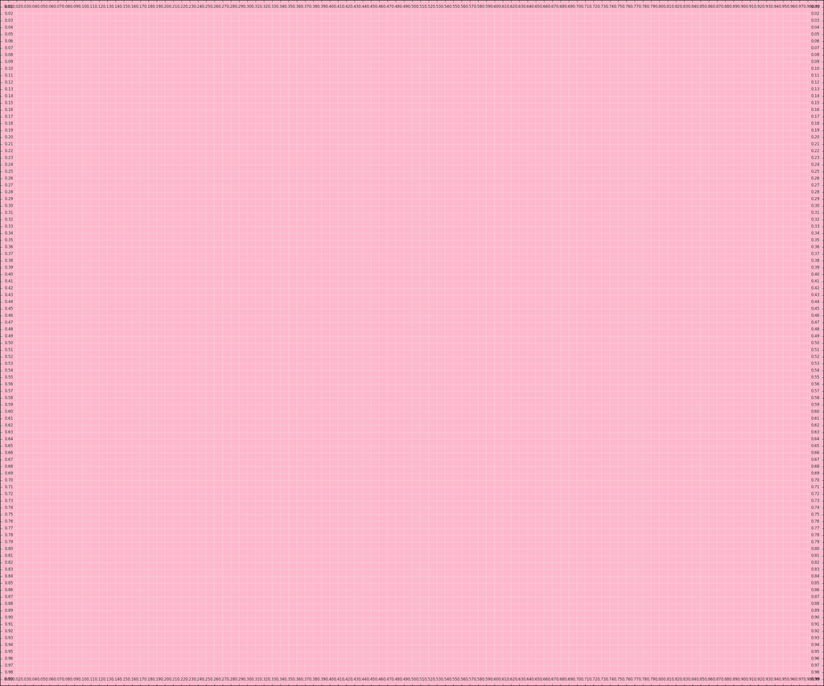

```python
img2 = img1.add_ticks(step=0.01, unit='ratio', color='black', fontsize=0.008)
img2.show(width=500)
```

##### **10. 添加文本**

**函数签名:**

1. 语义化定位 (Semantic Mode): 不传 x, y 使用 position (e.g. "top_left") + offset (内边距) 来定位
2. 绝对坐标 (Absolute Mode): 传 x, y 使用 anchor (e.g. "center") 决定文字如何对齐到 (x, y)

**参数:**

- `text`: 文本内容
- `x`: 目标位置x (绝对坐标模式)
- `y`: 标位置y(绝对坐标模式)
- `loc`: 语义化位置, 不传入x, y时生效(支持: "center", "top", "bottom", "left", "right" 以及复合位置，如: top_left， 默认"top_left")
- `anchor`: 文字自身的锚点 (支持: "center", "top", "bottom", "left", "right" 以及复合位置，如: top_left， 在绝对坐标模式下默认center, 在语义化定位模式下默认与`loc`相同)
- `offset`: 内边距
- `unit`: 坐标/Offset 的单位(支持: "pixel", "ratio", "inch", "cm", "mm"，默认 "ratio")
- `fontsize`: 字体大小
  - int: 像素值 (e.g. 24)
  - float < 1.0: 相对高度比例 (e.g. 0.05 = 5% image height)
- `fontweight`: 字重, 默认"normal"，支持常见的所有类型
- `rotation`: 文字旋转角度, 默认为0
- `color`: 文本颜色, 默认为"black"
- `font`: 字体名称, 默认"sans-serif"
- `box_style`: (可选) 文本边框样式, 需要传入字典 (例如: {'facecolor': 'white', 'edgecolor': 'red', 'boxstyle': 'round,pad=0.5,rounding_size=0.2'}), 与matplotlib相同
- `dpi`: (可选) 渲染时的目标 DPI, 默认与图片dpi相同

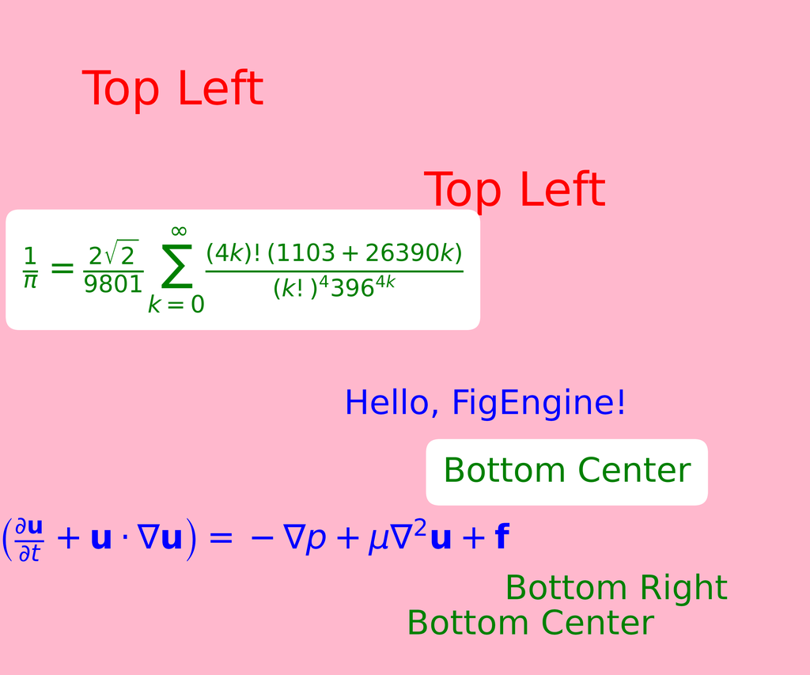

```python
img1_=img1.add_text("Hello, FigEngine!", loc="center", anchor="center",
                  fontsize=0.05, color="blue")
img1_=img1_.add_text("Top Left", loc="top_left", anchor="top_left",
                  fontsize=25, color="red")
img1_=img1_.add_text("Top Left", loc="top_right", anchor="top_right", offset=0.25,
                  unit="ratio", fontsize=25, color="red")
img1_=img1_.add_text("Bottom Right", x=0.9, y=0.9, unit="ratio", anchor="bottom_right",
                  fontsize=18, color="green")
img1_=img1_.add_text("Bottom Center", x=0.5, y=0.9, unit="ratio", anchor="top_left",
                  fontsize=18, color="green")
img1_=img1_.add_text("Bottom Center", x=0.7, y=0.7, unit="ratio", anchor="center",
                  fontsize=18, color="green", box_style={'facecolor': 'white', 'boxstyle': 'round,pad=0.5,rounding_size=0.4'})

formula_pi = r"$\frac{1}{\pi} = \frac{2\sqrt{2}}{9801} \sum_{k=0}^\infty \frac{(4k)!(1103+26390k)}{(k!)^4 396^{4k}}$"
img1_=img1_.add_text(formula_pi, x=0.3, y=0.4, unit="ratio", anchor="center",
                  fontsize=18, color="green", box_style={'facecolor': 'white', 'boxstyle': 'round,pad=0.5,rounding_size=0.4'})
formula_ns = r"$\rho \left( \frac{\partial \mathbf{u}}{\partial t} + \mathbf{u} \cdot \nabla \mathbf{u} \right) = -\nabla p + \mu \nabla^2 \mathbf{u} + \mathbf{f}$"
img1_=img1_.add_text(formula_ns, x=0.3, y=0.8, unit="ratio", anchor="center",
                  fontsize=18, color="blue")
img1_.show(width=500)
```

##### **11. 添加线条**

**函数签名:**

`Image.add_line(start, end, unit, color, width, arrow, arrow_size, arrow_style, arrow_angle, arrow_shorten, arrow_fill)`

**参数:**

- `start`: 起点坐标 (x1, y1)
- `end`: 终点坐标 (x2, y2)
- `unit`: 坐标单位 (支持: "pixel", "ratio", "inch", "cm", "mm"，默认 "ratio")
- `color`: 线条颜色
- `width`: 线条宽度
- `arrow`: 箭头位置 (支持: "start", "end", "both" 或 None, 默认 None)
- `arrow_size`: 箭头斜边长度 (像素)
- `arrow_style`: 箭头样式: (支持: "triangle", "open", "bar", "diamond", "circle", 默认: "triangle")
- `arrow_angle`: 箭头夹角(度), 仅triangle/open有效
- `arrow_shorten`: 主线缩短量, None 时默认=arrow_size*0.5
- `arrow_fill`: triangle/diamond 时是否填充(True=填充；False=只描边,默认填充)

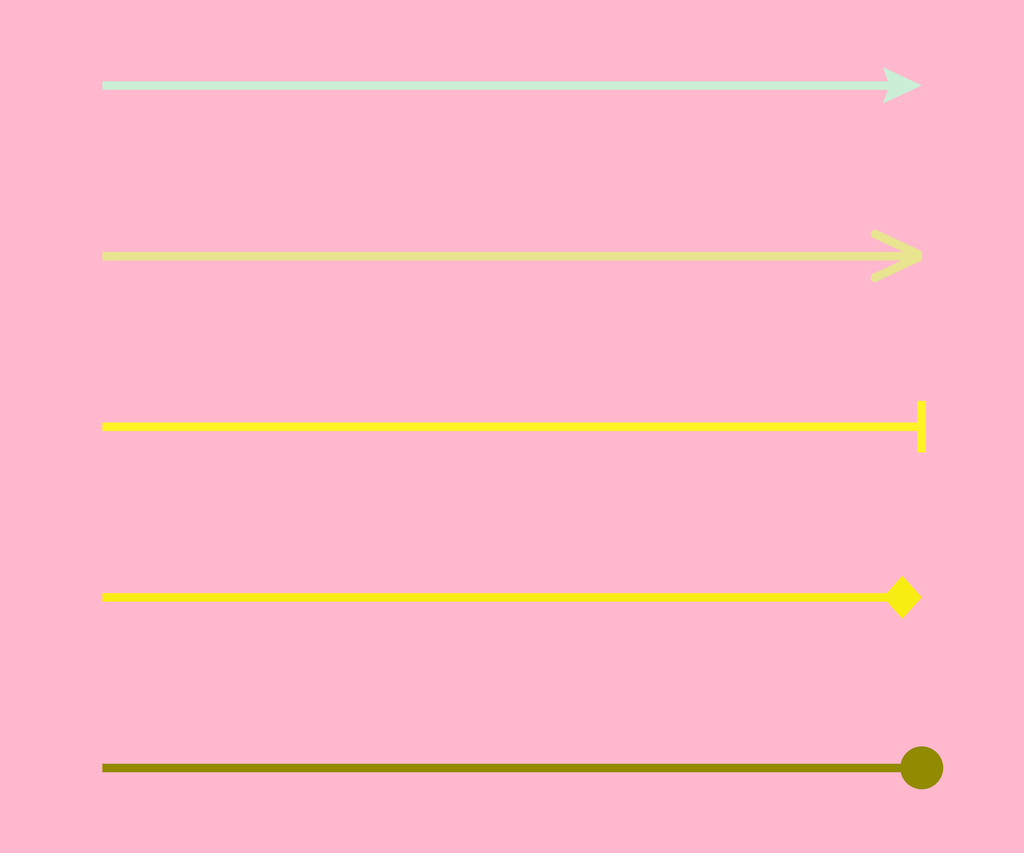

```python
img2 = img1.add_line(start=(0.1, 0.1), end=(0.9, 0.1), color="#CAEFD6", width=0.01, arrow="end", arrow_size=0.05, arrow_shorten=0.02, arrow_style="triangle")
img2 = img2.add_line(start=(0.1, 0.3), end=(0.9, 0.3), color="#E8E490", width=0.01, arrow="end", arrow_size=0.05, arrow_shorten=0.01, arrow_style="open")
img2 = img2.add_line(start=(0.1, 0.5), end=(0.9, 0.5), color="#FFF325", width=0.01, arrow="end", arrow_size=0.05, arrow_shorten=0.00, arrow_style="bar")
img2 = img2.add_line(start=(0.1, 0.7), end=(0.9, 0.7), color="#F8ED13", width=0.01, arrow="end", arrow_size=0.05, arrow_shorten=0.005, arrow_style="diamond")
img2 = img2.add_line(start=(0.1, 0.9), end=(0.9, 0.9), color="#928A01", width=0.01, arrow="end", arrow_size=0.05, arrow_shorten=0.01, arrow_style="circle")
img2.show(width=500)
```

##### **12. 添加特征点**

**函数签名:**

`Image.add_marker(x, y, unit, style, size, color, outline, width)`

**参数:**

- `x`: 目标位置x
- `y`: 标位置y
- `style`: 点的样式
  - `circle`: "●" 圆形
  - `square`: "■" 正方形
  - `diamond`: "◆" 菱形
  - `triangle_up`: "▲" 正三角
  - `triangle_down`: "▼" 倒三角
  - `pentagon`: "⬠" 五边形
  - `target`: "◎" 靶心
  - `plus`: "+" 加号
  - `cross`: "×" 叉号
- `size`: 点的大小
- `color`: 填充颜色
- `outline`: 边框颜色 (None 则无边框, 对 plus/cross 无效)
- `width`: 边框或线条宽度

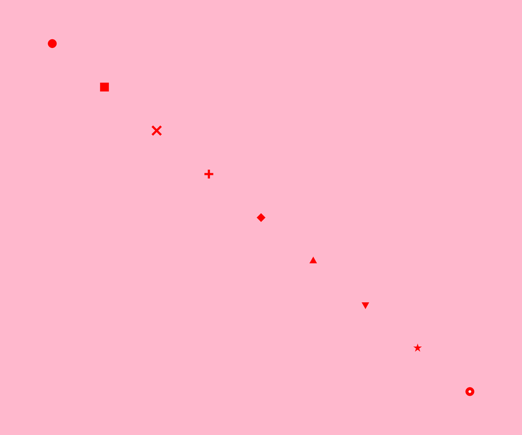

```python
img2 = img1.add_marker(x=0.1, y=0.1, unit="ratio", style="circle", size=0.02, color="red")
img2 = img2.add_marker(x=0.2, y=0.2, unit="ratio", style="square", size=0.02, color="red")
img2 = img2.add_marker(x=0.3, y=0.3, unit="ratio", style="cross", size=0.02, color="red", width=0.005)
img2 = img2.add_marker(x=0.4, y=0.4, unit="ratio", style="plus", size=0.02, color="red", width=0.005)
img2 = img2.add_marker(x=0.5, y=0.5, unit="ratio", style="diamond", size=0.02, color="red")
img2 = img2.add_marker(x=0.6, y=0.6, unit="ratio", style="triangle_up", size=0.02, color="red")
img2 = img2.add_marker(x=0.7, y=0.7, unit="ratio", style="triangle_down", size=0.02, color="red")
img2 = img2.add_marker(x=0.8, y=0.8, unit="ratio", style="star", size=0.02, color="red")
img2 = img2.add_marker(x=0.9, y=0.9, unit="ratio", style="target", size=0.02, color="red")
img2.show(width=500)
```

##### **13. 调整画布尺寸**

**函数签名:**

`Image.pad_to_size(target_size, unit, position, axis, bg_color)`

**参数:**

- `target_size`: 目标尺寸 (width, height)
- `unit`: 单位(支持: "pixel", "ratio", "inch", "cm", "mm"，默认 "pixel")
- `position`: 原图在新画布中的锚点位置 (支持: "center", "top", "bottom", "left", "right" 以及复合位置，如: top_left， 默认"center")
- `axis`: 仅调整某个轴向(支持: "both", "width", "height", 默认"both")
- `bg_color`: 新增区域的填充背景色， 默认透明

```python
print("原始比例", img1.size)

# 以比例模式进行填充
img2 = img1.pad_to_size(target_size=(1.1, 1.1), unit="ratio", bg_color="#B8FFCD")
print("以比例模式进行填充", img2.size)
# img2

img3 = img1.pad_to_size(target_size=(1900, 1600), unit="pixel", bg_color="#B8FFCD")
print("以像素模式进行填充", img3.size)
# img3
```

```
原始比例 (3600, 3000)
以比例模式进行填充 (3960, 3300)
以像素模式进行填充 (1900, 1600)
```

##### **14. 图片旋转**

**函数签名:**

`Image.rotate(angle, expand, bg_color)`

**参数:**

[output not shown]

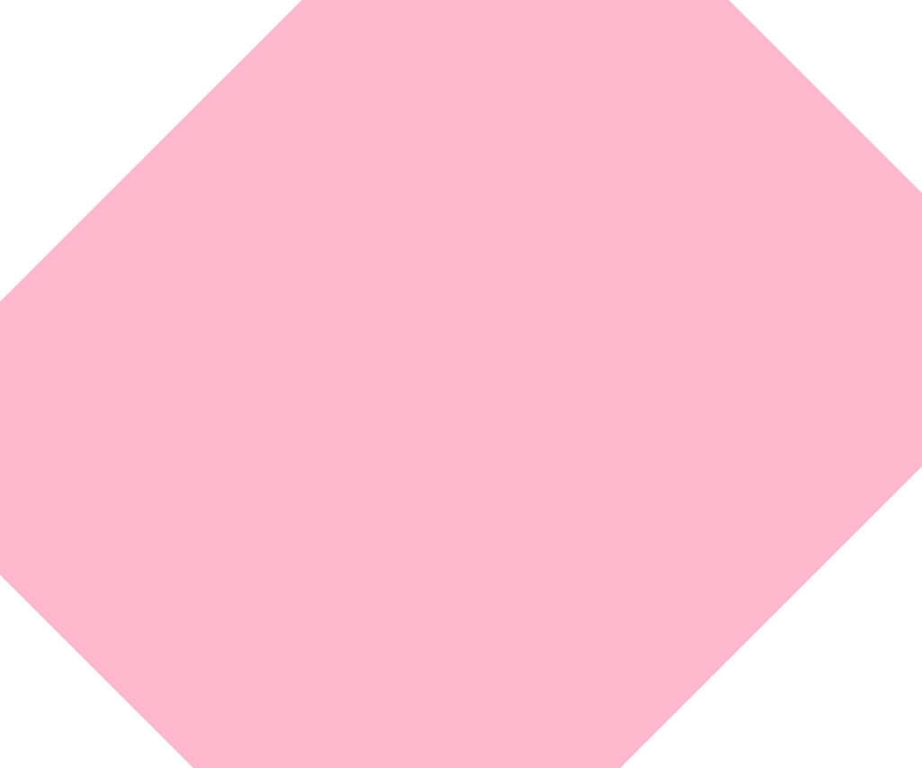

```python
img2 = img1.rotate(angle=45, expand=False, bg_color="#FFFFFF")
print("旋转45度并扩展画布", img2.size)
img2.show(width=500)
```

##### **15. 图片叠加**

**函数签名:**

`Image.overlay(other, x, y, anchor, unit, scale, expand, bg_color)`

**参数:**

- `other`: 要叠加的图片对象
- `x`: 叠加基准点 x
- `y`: 叠加基准点 y
- `anchor`: 叠加图片(other)自身的对齐点(支持: "center", "top", "bottom", "left", "right" 以及复合位置，如: top_left， 默认"center")
- `unit`: 单位(支持: "pixel", "ratio", "inch", "cm", "mm"，默认 "ratio")
- `scale`: 叠加图片(other)的缩放比例, 默认为1.0
- `expand`: 是否扩展画布
  - False: 裁剪超出边界的部分 (画中画模式)。
  - True: 自动扩大 Base 画布以容纳 Overlay (拼贴模式)。
- `bg_color`: 扩展画布时的背景色， 默认透明

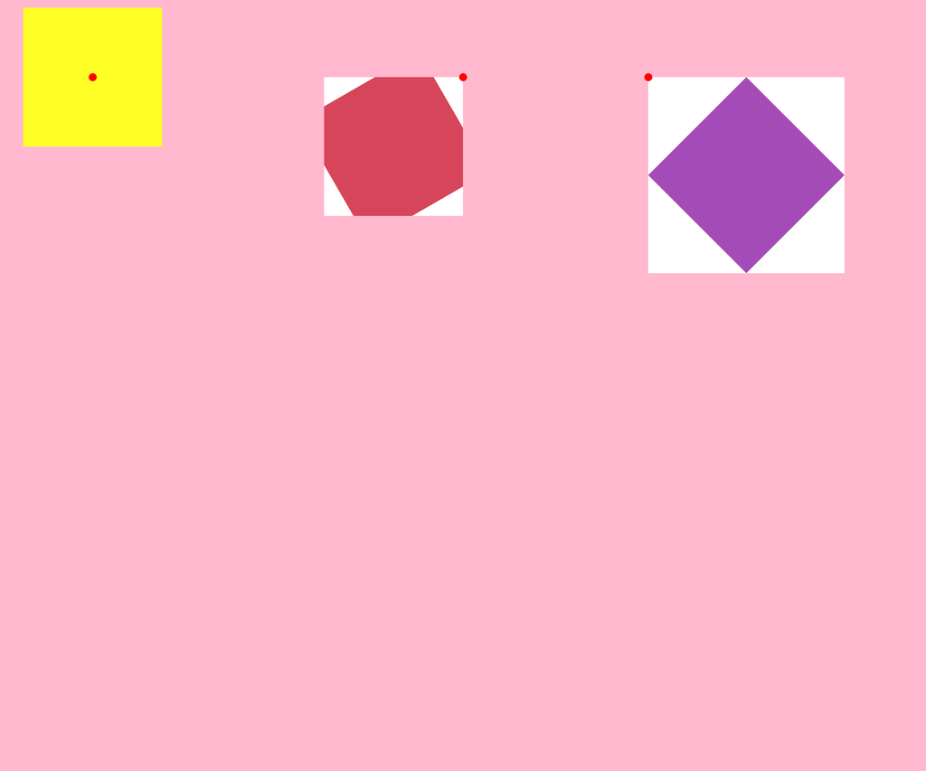

```python
# 创建一个空白的Image对象
img2 = fe.Image.new(size=(3.0, 3.0), facecolor="#FFFF25", unit="inch", dpi=DPI, label="Test Image")
img3 = fe.Image.new(size=(3.0, 3.0), facecolor="#A54BB7", unit="inch", dpi=DPI, label="Test Image")
img3 = img3.rotate(angle=-45, expand=True, bg_color="#FFFFFF")
img4 = fe.Image.new(size=(3.0, 3.0), facecolor="#D7455B", unit="inch", dpi=DPI, label="Test Image")
img4 = img4.rotate(angle=30, expand=False, bg_color="#FFFFFF")

# 叠加
img_ = img1.overlay(other=img2, x=0.1, y=0.1, unit="ratio", anchor="center", scale=0.3)
img_ = img_.overlay(other=img3, x=0.7, y=0.1, unit="ratio", anchor="top_left", scale=0.3)
img_ = img_.overlay(other=img4, x=0.5, y=0.1, unit="ratio", anchor="top_right", scale=0.3)
img_ = img_.add_marker(x=0.1, y=0.1, unit="ratio", style="circle", size=0.01, color="red")
img_ = img_.add_marker(x=0.7, y=0.1, unit="ratio", style="circle", size=0.01, color="red")
img_ = img_.add_marker(x=0.5, y=0.1, unit="ratio", style="circle", size=0.01, color="red")
img_.show(width=500)
```

##### **16. 图片标注**

**函数签名:**

**参数:**

- `label`: (可选) 强制指定标签内容, 默认使用初始化时的 label
- `loc`: 位置(默认, "top_left")
- `offset`: 距离边缘的内边距, 建议使用 tuple (x_off, y_off) 做微调, 默认 (0.02, 0.02) 表示宽高各 2% 的间距
- `format_str`: 格式化字符串(默认: "({})")
  - "({})" -> "(a)"
  - "{}" -> "a"
  - "{}." -> "a."
  - "Fig. {}" -> "Fig. a"
- `case`: 大小写转换(默认: 强制小写)
  - "upper": 强制大写 (a -> A)
  - "lower": 强制小写 (A -> a)
- `fontsize`: 字体大小, 与matplotlib一致
- `fontweight`: 字重(默认: "bold")
- `color`: 颜色(默认: "black")
- `font`: 字体
- `box_style`: 背景框样式 (默认: 透明), 与add_text一致

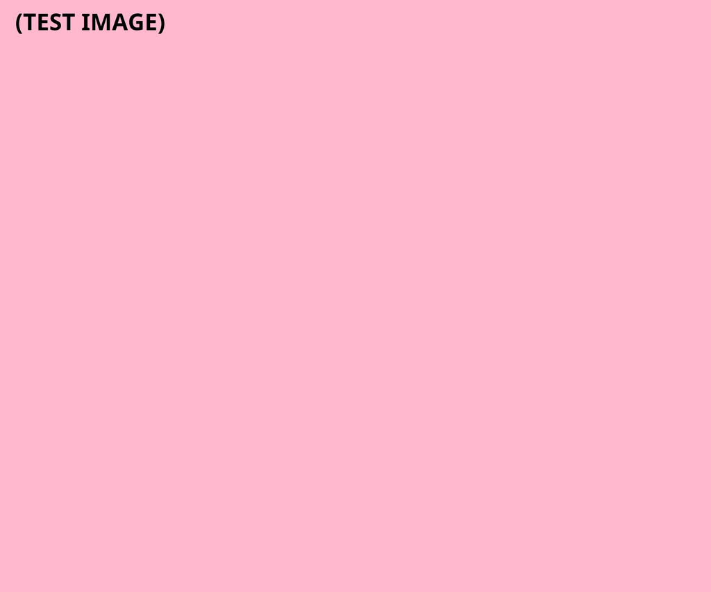

```python
img1_ = img1.labeled(format_str="({})", fontsize=14, case="upper", font="Noto Sans")
img1_.show(width=500)
```